# 📊 **S&P 500 Stock RNN Project!**

### 🌟 **Context**

Stock market data is fascinating to analyze to me, and strong predictive models can have **large financial payoffs**. The biggest theme is that, finding a **well-structured dataset** covering a wide array of companies can be challenging for many of the times given!

Our dataset provides **historical stock prices** for the last **5 years** for all companies currently listed on the **S&P 500 index**.

### 📂 **Content**

The dataset is available in two formats to suit various use cases:

1. **`all_stocks_5yr.csv`**: A single merged file containing stock data for all companies.
2. **`individual_stocks_5yr`**: A folder containing individual CSV files labeled by stock ticker name.

### 📈 **Columns in the Dataset**

#### 🎯 Let us dive into our data and uncover the trends driving the **S&P 500** shall we! 🚀

```python
# importing necessary libraries ...
import pandas as pd
import numpy as np


# loading my choosen dataset!
file_path = "all_stocks_5yr.csv"
data = pd.read_csv(file_path)
```

```python
# loading more necessary libraries ...
from sklearn.preprocessing import MinMaxScaler
from tensorflow.keras.models import Sequential
from tensorflow.keras.layers import LSTM, Dense
from sklearn.metrics import mean_squared_error, mean_absolute_error
import seaborn as sns
import matplotlib.pyplot as plt
```

```python
print(data.head())

# the ususal checking for null values and data types
print(data.info())
print(data.isnull().sum())
```

```
         date   open   high    low  close    volume Name
0  2013-02-08  15.07  15.12  14.63  14.75   8407500  AAL
1  2013-02-11  14.89  15.01  14.26  14.46   8882000  AAL
2  2013-02-12  14.45  14.51  14.10  14.27   8126000  AAL
3  2013-02-13  14.30  14.94  14.25  14.66  10259500  AAL
4  2013-02-14  14.94  14.96  13.16  13.99  31879900  AAL
<class 'pandas.core.frame.DataFrame'>
RangeIndex: 619040 entries, 0 to 619039
Data columns (total 7 columns):
 #   Column  Non-Null Count   Dtype
---  ------  --------------   -----
 0   date    619040 non-null  object
 1   open    619029 non-null  float64
 2   high    619032 non-null  float64
 3   low     619032 non-null  float64
 4   close   619040 non-null  float64
 5   volume  619040 non-null  int64
 6   Name    619040 non-null  object
dtypes: float64(4), int64(1), object(2)
memory usage: 33.1+ MB
None
date       0
open      11
high       8
low        8
close      0
volume     0
Name       0
dtype: int64
```

```python
print(data.head())
```

```
         date   open   high    low  close    volume Name
0  2013-02-08  15.07  15.12  14.63  14.75   8407500  AAL
1  2013-02-11  14.89  15.01  14.26  14.46   8882000  AAL
2  2013-02-12  14.45  14.51  14.10  14.27   8126000  AAL
3  2013-02-13  14.30  14.94  14.25  14.66  10259500  AAL
4  2013-02-14  14.94  14.96  13.16  13.99  31879900  AAL
```

```python
# looking into any unique stock tickers
print("Unique Stock Tickers:", data['Name'].nunique())
print(data['Name'].unique())
```

```
Unique Stock Tickers: 505
['AAL' 'AAPL' 'AAP' 'ABBV' 'ABC' 'ABT' 'ACN' 'ADBE' 'ADI' 'ADM' 'ADP'
 'ADSK' 'ADS' 'AEE' 'AEP' 'AES' 'AET' 'AFL' 'AGN' 'AIG' 'AIV' 'AIZ' 'AJG'
 'AKAM' 'ALB' 'ALGN' 'ALK' 'ALLE' 'ALL' 'ALXN' 'AMAT' 'AMD' 'AME' 'AMGN'
 'AMG' 'AMP' 'AMT' 'AMZN' 'ANDV' 'ANSS' 'ANTM' 'AON' 'AOS' 'APA' 'APC'
 'APD' 'APH' 'APTV' 'ARE' 'ARNC' 'ATVI' 'AVB' 'AVGO' 'AVY' 'AWK' 'AXP'
 'AYI' 'AZO' 'A' 'BAC' 'BAX' 'BA' 'BBT' 'BBY' 'BDX' 'BEN' 'BF.B' 'BHF'
 'BHGE' 'BIIB' 'BK' 'BLK' 'BLL' 'BMY' 'BRK.B' 'BSX' 'BWA' 'BXP' 'CAG'
 'CAH' 'CAT' 'CA' 'CBG' 'CBOE' 'CBS' 'CB' 'CCI' 'CCL' 'CDNS' 'CELG' 'CERN'
 'CFG' 'CF' 'CHD' 'CHK' 'CHRW' 'CHTR' 'CINF' 'CI' 'CLX' 'CL' 'CMA' 'CMCSA'
 'CME' 'CMG' 'CMI' 'CMS' 'CNC' 'CNP' 'COF' 'COG' 'COL' 'COO' 'COP' 'COST'
 'COTY' 'CPB' 'CRM' 'CSCO' 'CSRA' 'CSX' 'CTAS' 'CTL' 'CTSH' 'CTXS' 'CVS'
 'CVX' 'CXO' 'C' 'DAL' 'DE' 'DFS' 'DGX' 'DG' 'DHI' 'DHR' 'DISCA' 'DISCK'
 'DISH' 'DIS' 'DLR' 'DLTR' 'DOV' 'DPS' 'DRE' 'DRI' 'DTE' 'DUK' 'DVA' 'DVN'
 'DWDP' 'DXC' 'D' 'EA' 'EBAY' 'ECL' 'ED' 'EFX' 'EIX' 'EL' 'EMN' 'EMR'
 'EOG' 'EQIX' 'EQR' 'EQT' 'ESRX' 'ESS' 'ES' 'ETFC' 'ETN' 'ETR' 'EVHC' 'EW'
 'EXC' 'EXPD' 'EXPE' 'EXR' 'FAST' 'FBHS' 'FB' 'FCX' 'FDX' 'FE' 'FFIV'
 'FISV' 'FIS' 'FITB' 'FLIR' 'FLR' 'FLS' 'FL' 'FMC' 'FOXA' 'FOX' 'FRT'
 'FTI' 'FTV' 'F' 'GD' 'GE' 'GGP' 'GILD' 'GIS' 'GLW' 'GM' 'GOOGL' 'GOOG'
 'GPC' 'GPN' 'GPS' 'GRMN' 'GS' 'GT' 'GWW' 'HAL' 'HAS' 'HBAN' 'HBI' 'HCA'
 'HCN' 'HCP' 'HD' 'HES' 'HIG' 'HII' 'HLT' 'HOG' 'HOLX' 'HON' 'HPE' 'HPQ'
 'HP' 'HRB' 'HRL' 'HRS' 'HSIC' 'HST' 'HSY' 'HUM' 'IBM' 'ICE' 'IDXX' 'IFF'
 'ILMN' 'INCY' 'INFO' 'INTC' 'INTU' 'IPG' 'IP' 'IQV' 'IRM' 'IR' 'ISRG'
 'ITW' 'IT' 'IVZ' 'JBHT' 'JCI' 'JEC' 'JNJ' 'JNPR' 'JPM' 'JWN' 'KEY' 'KHC'
 'KIM' 'KLAC' 'KMB' 'KMI' 'KMX' 'KORS' 'KO' 'KR' 'KSS' 'KSU' 'K' 'LB'
 'LEG' 'LEN' 'LH' 'LKQ' 'LLL' 'LLY' 'LMT' 'LNC' 'LNT' 'LOW' 'LRCX' 'LUK'
 'LUV' 'LYB' 'L' 'MAA' 'MAC' 'MAR' 'MAS' 'MAT' 'MA' 'MCD' 'MCHP' 'MCK'
 'MCO' 'MDLZ' 'MDT' 'MET' 'MGM' 'MHK' 'MKC' 'MLM' 'MMC' 'MMM' 'MNST' 'MON'
 'MOS' 'MO' 'MPC' 'MRK' 'MRO' 'MSFT' 'MSI' 'MS' 'MTB' 'MTD' 'MU' 'MYL' 'M'
 'NAVI' 'NBL' 'NCLH' 'NDAQ' 'NEE' 'NEM' 'NFLX' 'NFX' 'NI' 'NKE' 'NLSN'
 'NOC' 'NOV' 'NRG' 'NSC' 'NTAP' 'NTRS' 'NUE' 'NVDA' 'NWL' 'NWSA' 'NWS'
 'OKE' 'OMC' 'ORCL' 'ORLY' 'OXY' 'O' 'PAYX' 'PBCT' 'PCAR' 'PCG' 'PCLN'
 'PDCO' 'PEG' 'PEP' 'PFE' 'PFG' 'PGR' 'PG' 'PHM' 'PH' 'PKG' 'PKI' 'PLD'
 'PM' 'PNC' 'PNR' 'PNW' 'PPG' 'PPL' 'PRGO' 'PRU' 'PSA' 'PSX' 'PVH' 'PWR'
 'PXD' 'PX' 'PYPL' 'QCOM' 'QRVO' 'RCL' 'REGN' 'REG' 'RE' 'RF' 'RHI' 'RHT'
 'RJF' 'RL' 'RMD' 'ROK' 'ROP' 'ROST' 'RRC' 'RSG' 'RTN' 'SBAC' 'SBUX' 'SCG'
 'SCHW' 'SEE' 'SHW' 'SIG' 'SJM' 'SLB' 'SLG' 'SNA' 'SNI' 'SNPS' 'SO' 'SPGI'
 'SPG' 'SRCL' 'SRE' 'STI' 'STT' 'STX' 'STZ' 'SWKS' 'SWK' 'SYF' 'SYK'
 'SYMC' 'SYY' 'TAP' 'TDG' 'TEL' 'TGT' 'TIF' 'TJX' 'TMK' 'TMO' 'TPR' 'TRIP'
 'TROW' 'TRV' 'TSCO' 'TSN' 'TSS' 'TWX' 'TXN' 'TXT' 'T' 'UAA' 'UAL' 'UA'
 'UDR' 'UHS' 'ULTA' 'UNH' 'UNM' 'UNP' 'UPS' 'URI' 'USB' 'UTX' 'VAR' 'VFC'
 'VIAB' 'VLO' 'VMC' 'VNO' 'VRSK' 'VRSN' 'VRTX' 'VTR' 'VZ' 'V' 'WAT' 'WBA'
 'WDC' 'WEC' 'WFC' 'WHR' 'WLTW' 'WMB' 'WMT' 'WM' 'WRK' 'WU' 'WYNN' 'WYN'
 'WY' 'XEC' 'XEL' 'XLNX' 'XL' 'XOM' 'XRAY' 'XRX' 'XYL' 'YUM' 'ZBH' 'ZION'
 'ZTS']
```

```python
print("Duplicate Rows:", data.duplicated().sum())
```

```
Duplicate Rows: 0
```

## **🔢 Data Preprocessing**

**Normalization**: We do a bit of rescaling all numerical values to the [0, 1] range so we can ensure of our stable model performance!

**Feature Engineering**: Later I also decided to create sequences of 30 days of historical data to predict the next day’s stock price. It turned out more helpful than I expected!

**Shaping Inputs**: Also did a bit of reshaping of our data into format (samples, time steps, features) that are ofcourse required for LSTM networks.

```python
# converting 'date' to datetime to prepare for time-series analysis!
data['date'] = pd.to_datetime(data['date'])
```

```python
# upting missing values here as well
data.fillna(method='ffill', inplace=True)
```

```python
print(data.isnull().sum())
```

```
date      0
open      0
high      0
low       0
close     0
volume    0
Name      0
dtype: int64
```

```python
# now we can finally filter our data for a single stock for now ...
selected_stock = 'AAL'
stock_data = data[data['Name'] == selected_stock].sort_values('date')
print(stock_data.head())
```

```
        date   open   high    low  close    volume Name
0 2013-02-08  15.07  15.12  14.63  14.75   8407500  AAL
1 2013-02-11  14.89  15.01  14.26  14.46   8882000  AAL
2 2013-02-12  14.45  14.51  14.10  14.27   8126000  AAL
3 2013-02-13  14.30  14.94  14.25  14.66  10259500  AAL
4 2013-02-14  14.94  14.96  13.16  13.99  31879900  AAL
```

```python
# going to go ahead and drop our 'Name' column for single-stock analysis
stock_data.drop(columns=['Name'], inplace=True)
```

```python
# practing feature engineering a bit to add some depth to the dataset!
# we are adding 1. daily price change, 2. percentage price change, 3. moving averages

stock_data['price_change'] = stock_data['close'] - stock_data['open']
stock_data['percent_change'] = (stock_data['price_change'] / stock_data['open']) * 100
stock_data['7_day_MA'] = stock_data['close'].rolling(window=7).mean()
stock_data['30_day_MA'] = stock_data['close'].rolling(window=30).mean()
```

```python
# normalizing some cols here ... a bit of scaling too.
columns_to_normalize = ['open', 'high', 'low', 'close', 'volume']
scaler = MinMaxScaler()
```

```python
stock_data[columns_to_normalize] = scaler.fit_transform(stock_data[columns_to_normalize])
```

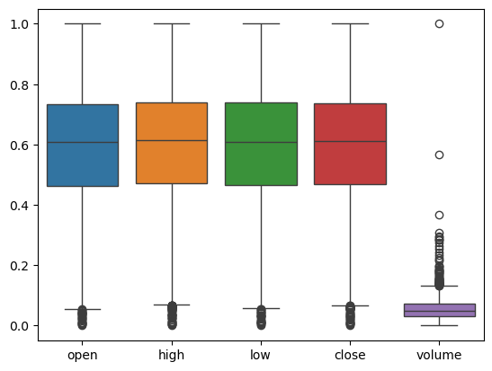

```python
# looking for any outliers before we progress ...
sns.boxplot(data=stock_data[['open', 'high', 'low', 'close', 'volume']])
plt.show()
```

open, high, low, and close are all relatively symmetrical - volume has significant outliers worth notifying ... we are going to go ahead and cap them as this may skew our work later on or even overwhelm our model too!

## **Starting a bit of EDA Below** ...

```python
# cap volume outliers only for now ....
Q1 = stock_data['volume'].quantile(0.25)
Q3 = stock_data['volume'].quantile(0.75)
IQR = Q3 - Q1

# capping volume that are at 1.5 * IQR
lower_bound = Q1 - 1.5 * IQR
upper_bound = Q3 + 1.5 * IQR
stock_data['volume'] = stock_data['volume'].clip(lower=lower_bound, upper=upper_bound)
```

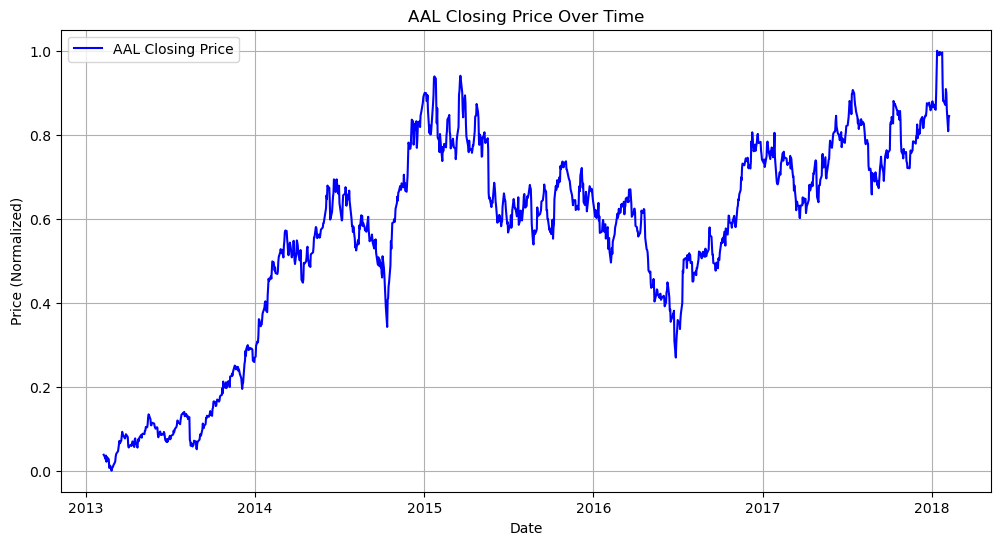

```python
# plotting our closing price over time ...
plt.figure(figsize=(12, 6))
plt.plot(stock_data['date'], stock_data['close'], label=f'{selected_stock} Closing Price', color='blue')
plt.title(f'{selected_stock} Closing Price Over Time')
plt.xlabel('Date')
plt.ylabel('Price (Normalized)')
plt.legend()
plt.grid()
plt.show()
```

We can see above that the stock experienced a significant uptrend from 2013 to mid-2015! It was then followed by some volatility and price corrections as we can see as well.

I do see some noticeable sharp drops, particularly around 2015 and 2016, which could correlate to market events or company-specific news.

Then, from 2017 onwards, our price shows more stable fluctuations compared to earlier periods ....

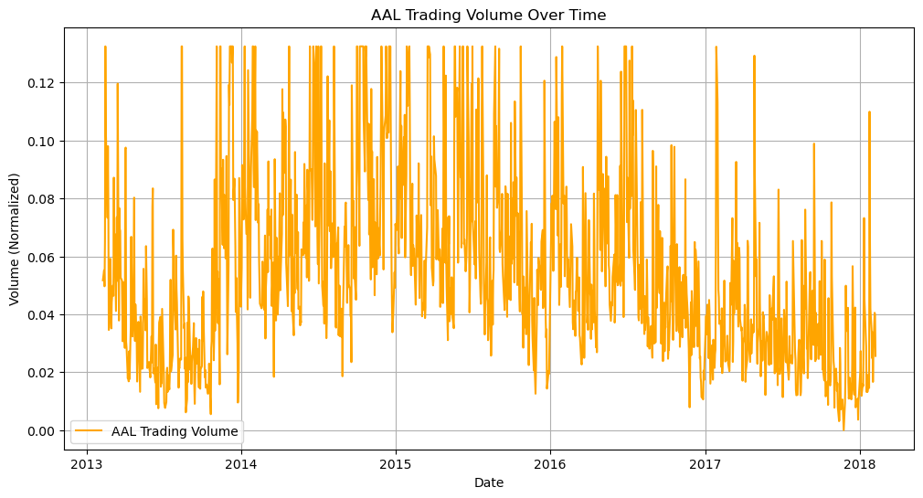

```python
# also plotting our trading volume over time
plt.figure(figsize=(12, 6))
plt.plot(stock_data['date'], stock_data['volume'], label=f'{selected_stock} Trading Volume', color='orange')
plt.title(f'{selected_stock} Trading Volume Over Time')
plt.xlabel('Date')
plt.ylabel('Volume (Normalized)')
plt.legend()
plt.grid()
plt.show()
```

Here, we can now see that the trading volume shows significant fluctuations, particularly between 2013 and 2015. There are also spikes in trading activity that could be associated with major market events or company-specific news.

Spikes in volume can sometimes correspond to price movements.

```python
summary_stats = stock_data[['open', 'high', 'low', 'close', 'volume']].describe()
print(summary_stats)
```

```
              open         high          low        close       volume
count  1259.000000  1259.000000  1259.000000  1259.000000  1259.000000
mean      0.553132     0.559254     0.557109     0.558267     0.055413
std       0.240243     0.242524     0.240436     0.241092     0.031689
min       0.000000     0.000000     0.000000     0.000000     0.000000
25%       0.461446     0.471091     0.465410     0.468867     0.031844
50%       0.608762     0.613436     0.609976     0.612761     0.049547
75%       0.732202     0.739542     0.738137     0.737404     0.072105
max       1.000000     1.000000     1.000000     1.000000     0.132496
```

#### Our Metrics Analysis Above:

All of our features are now normalized to a range of [0, 1], which is great for the future RNN training we will be doing! Then, our min values of 0 suggest that the data spans the entire range of normalized values.

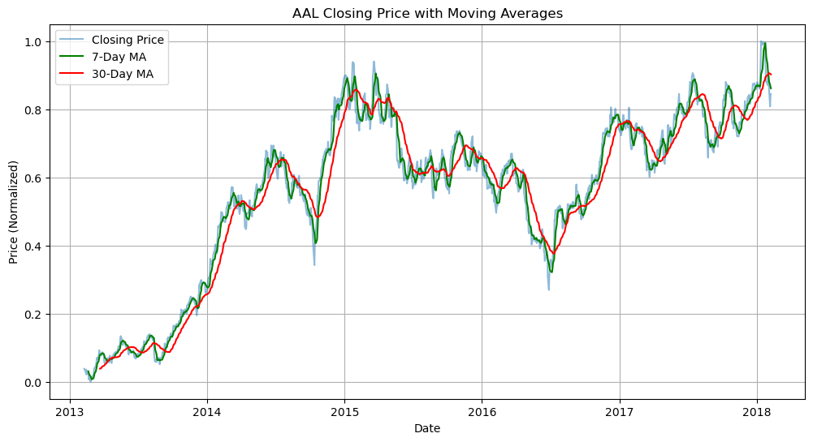

```python
# adding moving averages and plotting as well...
stock_data['7_day_MA'] = stock_data['close'].rolling(window=7).mean()
stock_data['30_day_MA'] = stock_data['close'].rolling(window=30).mean()

plt.figure(figsize=(12, 6))
plt.plot(stock_data['date'], stock_data['close'], label='Closing Price', alpha=0.5)
plt.plot(stock_data['date'], stock_data['7_day_MA'], label='7-Day MA', color='green')
plt.plot(stock_data['date'], stock_data['30_day_MA'], label='30-Day MA', color='red')
plt.title(f'{selected_stock} Closing Price with Moving Averages')
plt.xlabel('Date')
plt.ylabel('Price (Normalized)')
plt.legend()
plt.grid()
plt.show()
```

#### Our Metrics Analysis Above:

Our moving avgs are providing us an even cleaner view of our underlying trends in the closing price! We can see that the 7-day moving average very closely follows the actual price movements, while the 30-day moving average smooths them further.

We can also see that short-term volatility is evident from how closely the 7-day moving average tracks the actual price ... Longer-term trends, like the rise in 2013-2014 and dips in 2015-2016, are captured well by the 30-day moving average too!

```python
# going to only use our 'close' price for now
rnn_data = stock_data[['close']]
```

### **📊 Model Design & Architecture Overview:**

#### **🔹 Our Recurrent Neural Network (RNN) uses:**

1. **LSTM Layers**:
   - Capture sequential dependencies in stock price data over time!
   - You will see that later on we are experimenting with three activation functions: Sigmoid, Tanh, and ReLU.
2. **Stacked Architecture**:
   - **3 LSTM Layers**:
     - Layer 1 & 2: Return sequences for capturing deep temporal patterns ...
     - Layer 3: Then, this layes outputs a compressed feature vector for prediction ...
3. **Dense Output Layer**:
   - Single neuron for predicting the normalized closing price ...

#### **💡 Key Features:**

- Sequence Length: **30 timesteps**.
- Feature Input: **1 feature** (Normalized closing price).
- Output: Predicted **next day’s closing price**.

```python
# defining our window size first ...
window_size = 30

# creating a function to call the and create our sequences
def create_sequences(data, window_size):
    X, y = [], []
    for i in range(len(data) - window_size):
        X.append(data[i:i+window_size])
        y.append(data[i+window_size])
    return np.array(X), np.array(y)

# we will get an input-output sequences here
X, y = create_sequences(rnn_data['close'].values, window_size)
print("Shape of X:", X.shape)
print("Shape of y:", y.shape)
```

```
Shape of X: (1229, 30)
Shape of y: (1229,)
```

```python
# splitting our training and testing sets now! the usual process ....
split_index = int(0.8 * len(X))
X_train, X_test = X[:split_index], X[split_index:]
y_train, y_test = y[:split_index], y[split_index:]
```

```python
print("Training set shape:", X_train.shape, y_train.shape)
print("Testing set shape:", X_test.shape, y_test.shape)
```

```
Training set shape: (983, 30) (983,)
Testing set shape: (246, 30) (246,)
```

```python
X_train = X_train.reshape((X_train.shape[0], X_train.shape[1], 1))
```

```python
X_test = X_test.reshape((X_test.shape[0], X_test.shape[1], 1))
```

```python
print("RNN input shape:", X_train.shape)
```

```
RNN input shape: (983, 30, 1)
```

```python
# now we are designing our RNN ...
model = Sequential([
    LSTM(64, activation='tanh', return_sequences=True, input_shape=(30, 1)),
    LSTM(64, activation='tanh', return_sequences=True),
    LSTM(32, activation='tanh'),
    Dense(1)
])

model.compile(optimizer='adam', loss='mse')
model.summary()
```

```
Model: "sequential"
_________________________________________________________________
 Layer (type)                Output Shape              Param #
=================================================================
 lstm (LSTM)                 (None, 30, 64)            16896

 lstm_1 (LSTM)               (None, 30, 64)            33024

 lstm_2 (LSTM)               (None, 32)                12416

 dense (Dense)               (None, 1)                 33

=================================================================
Total params: 62,369
Trainable params: 62,369
Non-trainable params: 0
_________________________________________________________________
```

[output not shown]

```python
history = model.fit(
    X_train, y_train,
    validation_data=(X_test, y_test),
    epochs=50,
    batch_size=32
)
```

[output not shown]

[output cut: 13 more lines]

[output not shown]

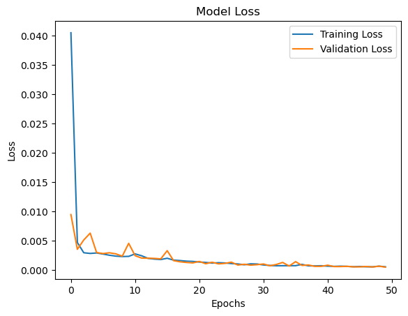

[output not shown]

```python
plt.plot(history.history['loss'], label='Training Loss')
plt.plot(history.history['val_loss'], label='Validation Loss')
plt.title('Model Loss')
plt.xlabel('Epochs')
plt.ylabel('Loss')
plt.legend()
plt.show()

# we are now going to predict and compare our loss!
predictions = model.predict(X_test)
```

We can see that our training loss began at about 0.0405 and reduced steadily to 5.84e-4 ... roughly! Our validation loss reduced similarly from 0.0095 to 5.32e-4, which I feel is a good indicator of generalization as well! In our current case, there doesn’t really appear to be overfitting as the training and validation losses are close to each other throughout!

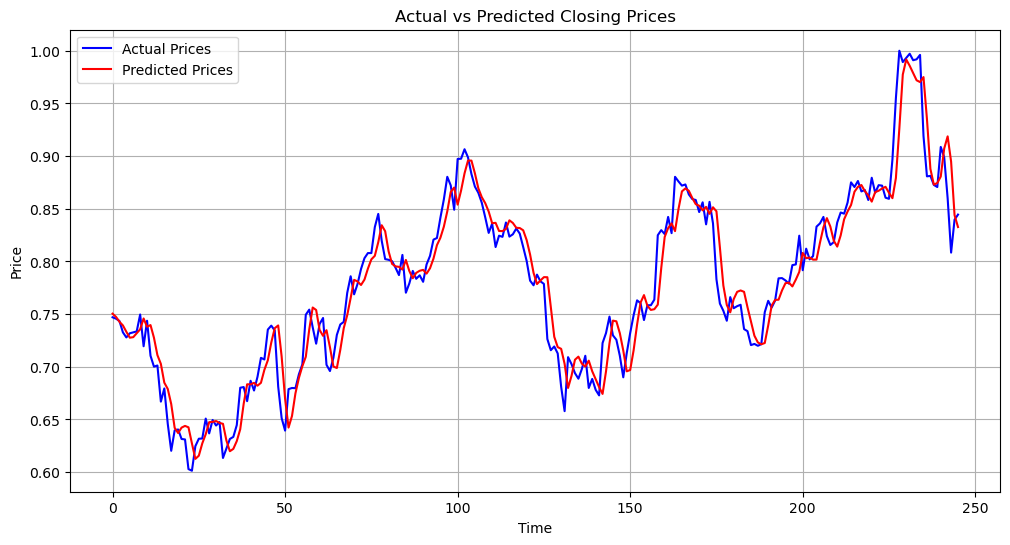

```python
predictions = model.predict(X_test)
plt.figure(figsize=(12, 6))
plt.plot(y_test, label='Actual Prices', color='blue')
plt.plot(predictions, label='Predicted Prices', color='red')
plt.title('Actual vs Predicted Closing Prices')
plt.xlabel('Time')
plt.ylabel('Price')
plt.legend()
plt.grid()
plt.show()
```

#### Our Metrics Analysis Above:

Red (predicted prices) and blue (actual prices) lines closely follow each other. This is once again, indicating to us that our RNN has captured the overall trends and patterns in the data effectively!

There are just a few points where our predicted prices slightly lag or overshoot the actual prices. I've read that this is common in time-series models due to the inherent complexity of stock price movement.

Our model performs well in predicting both upward and downward trends. This is a strong indicator of its effectiveness I feel like!

```python
mse = mean_squared_error(y_test, predictions)
mae = mean_absolute_error(y_test, predictions)
```

```python
print("Mean Squared Error:", mse)
print("Mean Absolute Error:", mae)
```

```
Mean Squared Error: 0.0005324394445571244
Mean Absolute Error: 0.017105372566383434
```

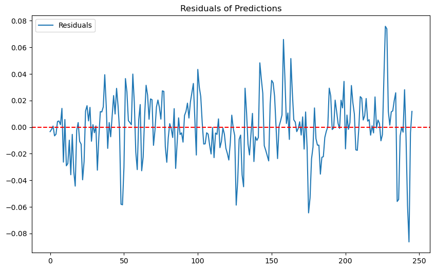

```python
residuals = y_test - predictions.flatten()
plt.figure(figsize=(10, 6))
plt.plot(residuals, label='Residuals')
plt.axhline(0, color='red', linestyle='--')
plt.title('Residuals of Predictions')
plt.legend()
plt.show()
```

#### Our Metrics Analysis Above:

Mean Squared Error (MSE): --> 0.000532 This is giving us a low value that suggests that our model is making small squared errors on (average) when predicting the closing prices.

Mean Absolute Error (MAE): --> 0.0171 On average, our predictions are off by approximately 1.71% (since our data was normalized previously as we demonstrated).

Overall, our model is showing us a strong ability to capture the trends and movements of stock prices with minimal errors. The low MSE and MAE values indicate that the RNN is effective for this prediction task!

```python
last_sequence = stock_data['close'].values[-30:].reshape(1, 30, 1)
last_sequence = np.array(last_sequence, dtype=np.float32)
```

```python
# debugging last_sequence ...
print("Shape of last_sequence:", last_sequence.shape)
```

```
Shape of last_sequence: (1, 30, 1)
```

```python
# debugging last_sequence ...
last_sequence = np.array(last_sequence, dtype=np.float32)
print("Data type of last_sequence:", last_sequence.dtype)
```

```
Data type of last_sequence: float32
```

```python
# debugging last_sequence ...
last_sequence = stock_data['close'].values[-30:]

# reshaping here to (1, 30, 1)
last_sequence = last_sequence.reshape(1, 30, 1).astype(np.float32)
print("Final Shape of last_sequence:", last_sequence.shape)
```

```
Final Shape of last_sequence: (1, 30, 1)
```

```python
print("Shape of X_train:", X_train.shape)
```

```
Shape of X_train: (983, 30, 1)
```

```python
model.compile(optimizer='adam', loss='mse')
```

```python
next_day_prediction = model.predict(last_sequence)
print("Predicted next day's closing price (normalized):", next_day_prediction[0][0])
```

[output not shown]

```
Predicted next day's closing price (normalized): 0.8423959
```

#### Predicted Next Day's Closing Price (Normalized):

0.8424:

This is our normalized prediction for the next day! wohoooo

## **🚀 Activation Functions Experimentation**

- Activation functions tested: Sigmoid, Tanh, ReLU
- Observing performance differences across metrics.

### **Observations ~**

- **Sigmoid**: This function I feel like struggled to capture the fullest of complexity of our sequential data.
- **Tanh**: Yet again, Tanh achieved the best performance with the lowest MSE and MAE! It also demonstrated stable validation loss and is well-suited for normalized sequential data.
- **ReLU**: Less effective in handling this dataset, likely due to the risk of dying neurons when processing normalized values (potentially!).

```python
model.compile(optimizer='adam', loss='mse', metrics=['mae'])
```

```
Training Model with Activation Function: sigmoid


Training Model with Activation Function: tanh
```

[output not shown]

[output cut: 30 more lines]

[output not shown]

```
Training Model with Activation Function: relu
```

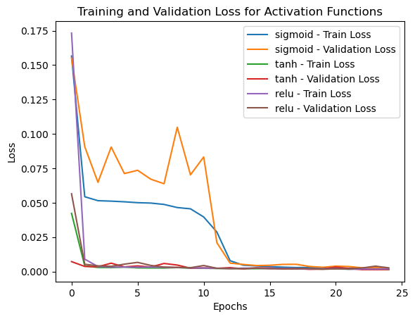

```
sigmoid - MSE: 0.0023187180049717426, MAE: 0.03831221163272858
tanh - MSE: 0.001414979575201869, MAE: 0.02991451509296894
relu - MSE: 0.002628330374136567, MAE: 0.0418139211833477
```

```python
activation_functions = ['sigmoid', 'tanh', 'relu']
my_results = {}

for activation in activation_functions:
    print(f"\nTraining Model with Activation Function: {activation}\n")

    model = Sequential([
        LSTM(64, activation=activation, return_sequences=True, input_shape=(30, 1)),
        LSTM(64, activation=activation, return_sequences=True),
        LSTM(32, activation=activation),
        Dense(1)
    ])

    model.compile(optimizer='adam', loss='mse', metrics=['mae'])
    history = model.fit(X_train, y_train, epochs=25, batch_size=32, validation_data=(X_test, y_test), verbose=1)

    evaluation = model.evaluate(X_test, y_test, verbose=0, return_dict=True)
    mse = evaluation['loss']
    mae = evaluation['mae']

    my_results[activation] = {'MSE': mse, 'MAE': mae}

    plt.plot(history.history['loss'], label=f'{activation} - Train Loss')
    plt.plot(history.history['val_loss'], label=f'{activation} - Validation Loss')

plt.title('Training and Validation Loss for Activation Functions')
plt.xlabel('Epochs')
plt.ylabel('Loss')
plt.legend()
plt.show()

for activation, metrics in my_results.items():
    print(f"{activation} - MSE: {metrics['MSE']}, MAE: {metrics['MAE']}")
```

### **🔍 Some Observations on our given Activation Functions!**

#### **1. Sigmoid**

- **MSE**: `0.0023`
- **MAE**: `0.0383`
- It performed reasonably well but not as low as Tanh as we can see ....
- Biggest Take: Suitable but may struggle to capture the full complexity of the sequential data.

#### **2. Tanh**

- **MSE**: `0.0014`
- **MAE**: `0.0299`
- It achieved the **best performance** with the lowest MSE and MAE values! Wohoo!
- Biggest Take: I feel like it worked well for our sequential data, especially since we also normalized values. This is likely because it centers outputs around zero...

#### **3. ReLU**

- **MSE**: `0.0026`
- **MAE**: `0.0418`
- Tend to have higher errors compared to both Sigmoid and Tanh ...
- Biggest Take: May not handle this normalized sequential dataset as effectively as Tanh as we can see!

### **📊 Overall Analysis**

#### To do some further fine-tuning, I decided to go a bit further and test almost like a hybrid activation function setup ...

##### In this experiment, I'm going to use different activation functions in different layers of the LSTM model. I feel like this approach should leverage some of the strengths of multiple activation functions!

##### Tanh: For deeper sequential dependencies, especially in the initial layers!

##### ReLU: For capturing nonlinear relationships in later layers ...

##### Sigmoid: For compressing outputs when transitioning to the dense layer we have present ...

```python
print("\nTraining Model w/ a Hybrid Activation Functions\n")

model = Sequential([
    LSTM(64, activation='tanh', return_sequences=True, input_shape=(30, 1)),
    LSTM(64, activation='relu', return_sequences=True),
    LSTM(32, activation='sigmoid'),
    Dense(1)
])

model.compile(optimizer='adam', loss='mse', metrics=['mae'])
history = model.fit(X_train, y_train, epochs=25, batch_size=32, validation_data=(X_test, y_test), verbose=1)
evaluation = model.evaluate(X_test, y_test, verbose=0, return_dict=True)
mse = evaluation['loss']
mae = evaluation['mae']
```

### **Comparison of Activation Function Models-->**

[output not shown]

##### Hmm, not the bes tof results! We can see that our hybrid model showed higher MSE and MAE compared to individual activation function models, with Tanh performing best overall.

##### Tanh however, does continue to give us the most accurate predictions for our dataset!

##### Maybe mixing our activation functions may disrupt consistency in sequential data ...

```python
print("\nTraining Model with Adam Optimizer\n")

model = Sequential([
    LSTM(64, activation='tanh', return_sequences=True, input_shape=(30, 1)),
    LSTM(64, activation='tanh', return_sequences=True),
    LSTM(32, activation='tanh'),
    Dense(1)
])
```

[output not shown]

[output cut: 12 more lines]

[output not shown]

```
Adam Optimizer - MSE: 0.0007372941472567618, MAE: 0.020391853526234627
```

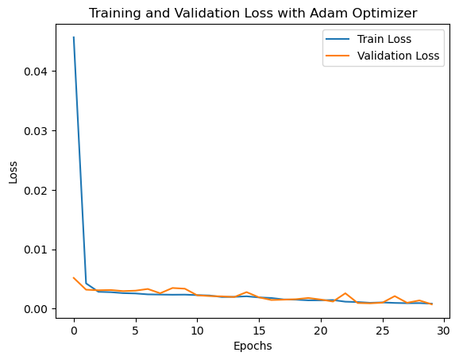

```python
model.compile(optimizer='adam', loss='mse', metrics=['mae'])
history = model.fit(X_train, y_train, epochs=30, batch_size=32, validation_data=(X_test, y_test), verbose=1)
evaluation = model.evaluate(X_test, y_test, verbose=0, return_dict=True)

mse = evaluation['loss']
mae = evaluation['mae']

print(f"Adam Optimizer - MSE: {mse}, MAE: {mae}")
plt.plot(history.history['loss'], label='Train Loss')
plt.plot(history.history['val_loss'], label='Validation Loss')
plt.title('Training and Validation Loss with Adam Optimizer')
plt.xlabel('Epochs')
plt.ylabel('Loss')
plt.legend()
plt.show()
```

### **🔍 Findings on our Adam Optimizer**

#### **Low Errors**:

- **MSE**: `0.000737`
- **MAE**: `0.0204`
- We can see that Adam achieved low error rates! This is demonstrating to us a strong performance for this stock price prediction task! This is good news to us.
- We can also see that Adam holds a stable convergence, therefore efficiently minimizing loss during it's training process ...
- I feel that our Aoptimizer almost one could say, dynamically, adjusts learning rates per parameter, leading to faster convergence like we mentioned earleir, in which it avoids issues like overshooting or plateauing too!

### **💡 Adam Summary**:

```python
# creating a df of a summary of all results
results_summary = {
    'Sigmoid': {'MSE': 0.0023, 'MAE': 0.0383},
    'Tanh': {'MSE': 0.0014, 'MAE': 0.0299},
    'ReLU': {'MSE': 0.0026, 'MAE': 0.0418},
    'Hybrid (Tanh, ReLU, Sigmoid)': {'MSE': 0.0042, 'MAE': 0.0542},
    'Adam Optimizer': {'MSE': 0.000737, 'MAE': 0.0204}
}
```

```python
results_df = pd.DataFrame.from_dict(results_summary, orient='index')
results_df.reset_index(inplace=True)
results_df.columns = ['Configuration', 'MSE', 'MAE']

print(results_df)
```

```
                  Configuration       MSE     MAE
0                       Sigmoid  0.002300  0.0383
1                          Tanh  0.001400  0.0299
2                          ReLU  0.002600  0.0418
3  Hybrid (Tanh, ReLU, Sigmoid)  0.004200  0.0542
4                Adam Optimizer  0.000737  0.0204
```

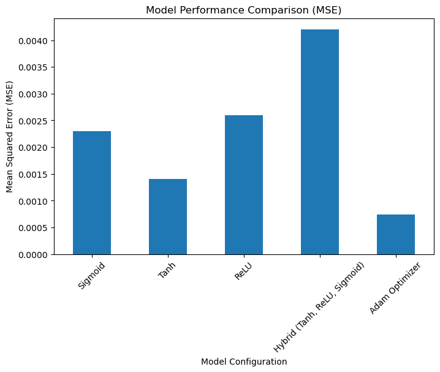

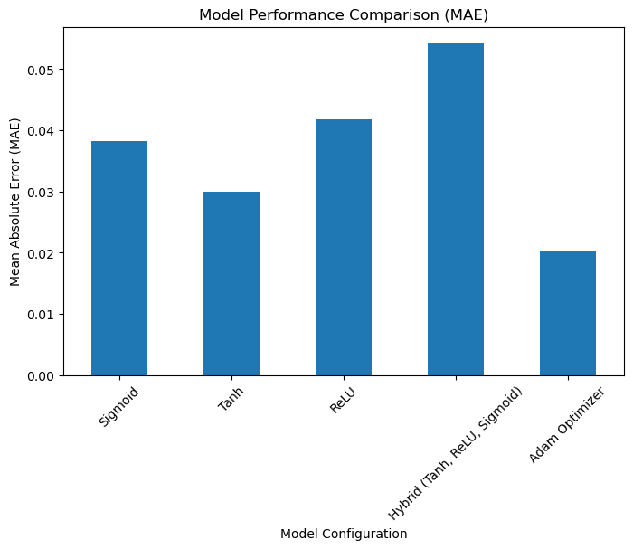

```python
results_df.plot(x='Configuration', y='MSE', kind='bar', legend=False, figsize=(8, 5))
plt.title('Model Performance Comparison (MSE)')
plt.ylabel('Mean Squared Error (MSE)')
plt.xlabel('Model Configuration')
plt.xticks(rotation=45)
plt.show()

results_df.plot(x='Configuration', y='MAE', kind='bar', legend=False, figsize=(8, 5))
plt.title('Model Performance Comparison (MAE)')
plt.ylabel('Mean Absolute Error (MAE)')
plt.xlabel('Model Configuration')
plt.xticks(rotation=45)
plt.show()
```

### **🔍 Some Key Findings from our Model Performance Visuals**

#### **📈 Mean Absolute Error (MAE):**

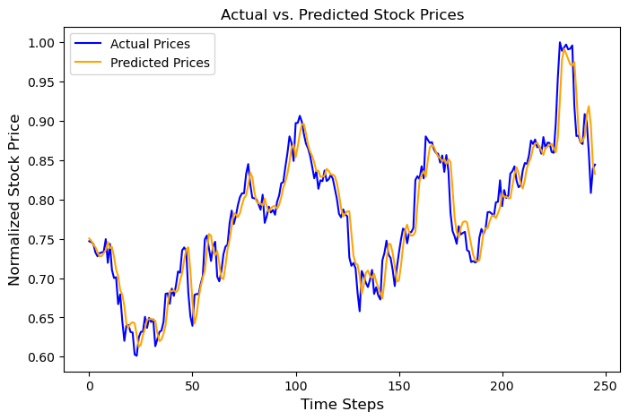

```python
plt.figure(figsize=(8, 5))
plt.plot(y_test, label='Actual Prices', color='blue')
plt.plot(predictions, label='Predicted Prices', color='orange')
plt.title('Actual vs. Predicted Stock Prices', fontsize=12)
plt.xlabel('Time Steps', fontsize=12)
plt.ylabel('Normalized Stock Price', fontsize=12)
plt.legend()
plt.show()
```

### **📈 Key Insights from Actual vs. Predicted Stock Prices**

- **Strong Alignment**: Here, we can closely see that our predicted stock prices (orange) closely follow the actual prices (blue), demonstrating the model's ability to capture trends effectively! This is just spot on I feel like.
- **Minor Deviations**: Small discrepancies are shown here but only at certain peaks and troughs. This is good because it's highlighting areas for potential refinement! Great crest to dive into later for future enhancement!
- **Validation**: All to say that this visualization also very much confirms the model's strong predictive capabilities for stock price movements! :D

```python
# sns.histplot(residuals, kde=True, color='teal', bins=20)
# plt.title('Distribution of Prediction Errors', fontsize=16)
# plt.xlabel('Residual (Actual - Predicted)', fontsize=12)
# plt.ylabel('Frequency', fontsize=10)
# plt.show()
# didnt end up being as insightful as i thought itd be ....
```

[figure not shown]

```python
plt.figure(figsize=(8, 5))
plt.plot(stock_data['date'], stock_data['close'], color='green', alpha=0.7)
plt.title('Historical Stock Prices', fontsize=10)
plt.xlabel('Date', fontsize=10)
plt.ylabel('Stock Price', fontsize=10)
plt.show()
```

### **🎉 Final Thoughts**:

- That was a journey! I feel like this project successfully showcased the power of RNNs, activation functions, and optimization techniques for time-series prediction. Our analysis demonstrated to us how intentional experimentation and evaluation has the ability to lead us meaningful insights- it's what we strive for most of the time right as data scientist?! 🚀

**What’s next?** I feel like with this solid foundation I've created, I can most definitely manage more future work with the techniques I've applied. I can explore and expand more complex models and reach towards even more advanced techniques like attention mechanisms maybe?! 💡

## **📊 Direct Dataset Link**

The dataset used for this project is the **S&P 500 Stock Price Data**, available on Kaggle. :)

🔗 **Dataset Link**: [S&P 500 Stock Price Data on Kaggle](https://www.kaggle.com/datasets/camnugent/sandp500/data)